# Group R Project

Eric O’Leary

## The Effect of Vaccination on Testing Rates (Eric O’Leary)

For this section of the notebook, we want to determine if vaccination rates have had an effect on testing rates. Our hypothesis is that an increase of vaccinations will cause a decrease in testing. Logically, as more individuals are vaccinated, fewer people can be infected, therefore fewer people would require testing.

##### Coding/Graphing

###### Coding/Graphing

The data we use is the Covid-19-Data from Owid, found at https://github.com/owid/covid-19-data/tree/master/public/data. First, we trim our data to be exclusively what we want: total vaccinations/tests over time for each country.

Through visual analysis of the ending trends of cumulative testing, the best scenario for our hypothesis - countries that have recently seen a decrease in tests - can be narrowed down to a list of roughly ten countries. We separate those countries and plot them in one graph. Then, we graph the vaccinations over time for the same ten countries chosen before.

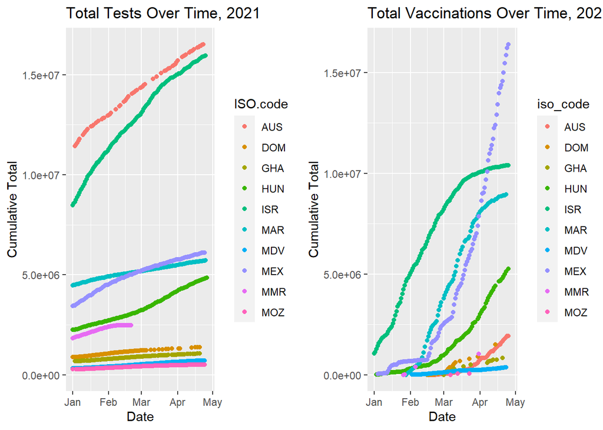

### Analysis

```
##    ISO Code Correlation Coefficient
## 1       AUS               0.9771095
## 2       DOM               0.9958426
## 3       GHA               0.9851323
## 4       HUN               0.9873159
## 5       ISR               0.9712250
## 6       MAR               0.9631002
## 7       MDV               0.9647846
## 8       MEX               0.9861004
## 9       MMR                      NA
## 10      MOZ              -0.4827567
```

There is not a universal correlation of increasing vaccination rates and decreasing testing rates. From our correlation coefficients, in eight of the ten chosen countries, there is a strong, positive relationship between total vaccinations and tests. But, our hypothesis was that there would be a negative relationship. The two outstanding correlation coefficients are for Myanmar and Mozambique. Myanmar does not have enough data to find a correlation coefficient, and Mozambique has a semi-strong negative relationship, but visual analysis suggests data is lacking here as well. There are a number of possible reasons for this. For one, the vaccines are still relatively new, and they may not have had enough time to cause a significant impact. Or, testing may still be required in some situations regardless of vaccination status. Whatever the reasoning, our hypothesis lacks strong evidence, even in the best of cases.